# MSBA_265_As_6

Khushbu Singh

2024-10-23

# Setting up Library needed

I will load movie data which is a CSV file into a data frame df and then will use read.csv(). It will displays the structure and a statistical summary of available data with str(), for that summary() for exploration.

```r
library(ggplot2)
library(dplyr)

# Loading the CSV data and storing in df
df <- read.csv("C:/Users/Khush/R. Studio/moviedata.csv")

# To print the data frame
str(df)
```

```
## 'data.frame':    13 obs. of  3 variables:
##  $ LevelOfViolence: int  1 1 1 2 2 3 5 4 1 3 ...
##  $ CriticsRating  : num  1.2 3.5 4.2 3.9 2.8 3 4.5 1.8 2.1 4.8 ...
##  $ Watched        : int  -1 1 1 1 -1 -1 -1 -1 -1 1 ...
```

```r
# To print data Summary
summary(df)
```

```
##  LevelOfViolence CriticsRating      Watched
##  Min.   :1.000   Min.   :1.200   Min.   :-1.0000
##  1st Qu.:1.000   1st Qu.:2.100   1st Qu.:-1.0000
##  Median :3.000   Median :3.000   Median :-1.0000
##  Mean   :2.615   Mean   :3.138   Mean   :-0.2308
##  3rd Qu.:3.000   3rd Qu.:4.200   3rd Qu.: 1.0000
##  Max.   :5.000   Max.   :4.900   Max.   : 1.0000
```

# Visualization of Data using ggplot

Plot displaying Critic Ratings vs.Level of Violence

- We will now visualize the relationship between violence, critic rating, and whether Ms. X watched the movie or not.
- The code uses `ggplot2` for scatter plot.
- It shows the relationship of critic ratings and the level of violence in movies.
- Each point is colored on the bases of whether Ms. X watched the movie, using `Watched` variable as a factor. The plot includes a title and labeled axes for clarity.

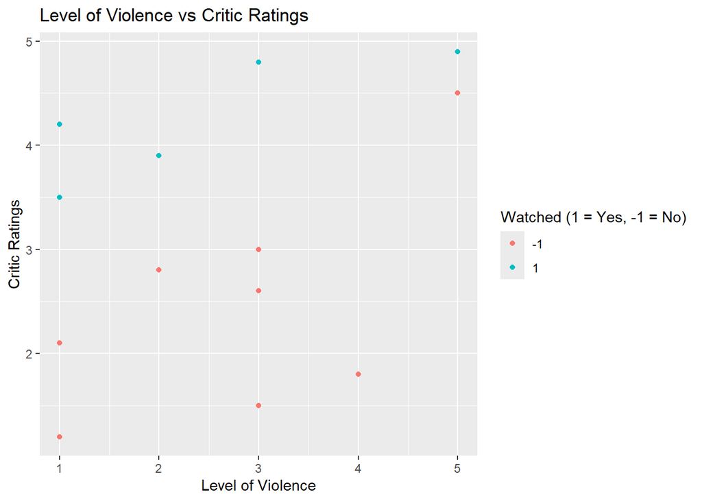

```r
# Plot level of violence vs. critic ratings and color by 'watched' status
ggplot(df, aes(x = LevelOfViolence, y = CriticsRating, color = factor(Watched))) +
  geom_point() +
  labs(title = "Level of Violence vs Critic Ratings", x ="Level of Violence" , y = "Critic Ratings", color = "Watched (1 = Yes, -1 = No)")
```

# Running the Perceptron Learning Algorithm (PLA) Training Process

- In this implementation, I have develop the Perceptron Learning Algorithm (PLA) from the ground up, manually coding the algorithm and updating the weights iteratively until it converges.
- The PLA works by repeatedly adjusting the weights and bias to correctly classify data points.
- For each data point, the algorithm calculates a linear combination, makes a prediction, and updates the weights and bias when the prediction is incorrect.
- This process continues until algorithm Converges or the maximum number of iterations is achieved. The final output includes the weights, bias, and the number of iterations.

```r
perceptron <- function(X, y, max_iter = 1000) {
  # Initialize weights for features and bias
  weights <- rep(0, ncol(X))  # Assign weights to zeros
  bias <- 0                   # Assign bias as Zeros
  num_iter <- 0               # Initialize number of iterations to 0
  done_training <- FALSE      # flag to track Convergence of training. Initialize with false value

  while (!done_training && num_iter < max_iter) {
    done_training <- TRUE #start with true if all sample are correctly classified that means training is converged
    num_iter <- num_iter + 1

    # Iterate over each data point
    for (i in 1:nrow(X)) {
      # Determine the linear combination (bias + dot product)
      output <- sum(weights * X[i, ]) + bias
      predicted_y <- ifelse(output >= 0, 1, -1)  # Prediction on the bases of output sign

      # Checking the prediction with the actual label to update weights and biases
      if (predicted_y!= y[i]) {
        # Update the bias and weights
        # new_weight = old_weight + yn* Xn
        weights <- weights + y[i] * X[i, ]
        bias <- bias + y[i]
        done_training  <- FALSE  # Since there is an update, training is not converged so we reset convergence flag to false
      }
    }
  }

  # Finalized weights, bias, and iteration total
  return(list(weights = weights, bias = bias, num_iter = num_iter))
}
```

# Running PLA

- The code organizes data (`CriticsRating` and `LevelOfViolence`) and target labels (`Watched`) as input into the perceptron algorithm. It executes the algorithm to train the model, capturing the resulting weights, bias, and iteration count. The output is presented with `cat()` to display the learned parameters and convergence information.

```r
# Prepare features and labels for input data
X <- as.matrix(df[, c("CriticsRating", "LevelOfViolence")])
# Using critic ratings and violence level as features
y <- df$Watched  # Target variable: indicates if Ms. X watched the movie

# Implement the perceptron algorithm
modelPla <- perceptron(X, y)

# Display the resulting weights, bias, and iteration count
cat("Trained Weights:", modelPla$weights, "\n")
```

```
## Trained Weights: 15.9 -9
```

```r
cat("Trained Bias:", modelPla$bias, "\n")
```

```
## Trained Bias: -32
```

```r
cat("numb_of_Iterations to Converge:", modelPla$num_iter, "\n")
```

```
## numb_of_Iterations to Converge: 44
```

# Calculate Slope and Intercept

- `calculate_slope_and_intercept()` is a helper function to calculate slope and intercept of decision boundary.
- **Input Arguments** : Weights and Bias of the trained model
- The function calculates slope and intercept of the decision boundary. It does not print anything but it will be used latter on by other functions

```r
calculate_slope_and_intercept <- function(modelPla) {
  w1 <- modelPla$weights[1]
  w2 <- modelPla$weights[2]
  bias <- modelPla$bias

  # Evaluate the slope and intercept of the decision boundary
  slope_value <- -w1 / w2
  intercept_value <- -bias / w2

  # Return slope and intercept to the caller function
  return(list(slope = slope_value, intercept = intercept_value))
}
```

# Model Report

- `report_model()` is a helper function to print slope and intercept of decision boundary.
- **Input Arguments** : Weights and Bias of the trained model
- The function uses `calculate_slope_and_intercept()` to get slope and intercept of the decision boundary and prints them on terminal.

```r
report_model <- function(modelPla) {
  # get slope and intercept of decision boundary
  result <-  calculate_slope_and_intercept(modelPla)
  slope <- result$slope # get slope value
  intercept <- result$intercept # get intercept value

  # Output of the decision boundary equation
  cat("The decision boundary equation is: \n")
  cat("LevelOfViolence =", slope, "* CriticsRating +", intercept, "\n")
}

# Call the function to display the model details
report_model(modelPla)
```

```
## The decision boundary equation is:
## LevelOfViolence = 1.766667 * CriticsRating + -3.555556
```

# Decision Boundary Plot

- `plot_decision_boundary()` is a helper function to plot the decision boundary.
- The function uses `calculate_slope_and_intercept()` to get slope and intercept of the decision boundary.
- Scatter plot of all the data points is displayed using `ggplot2` API.
- Decision boundary is plotted on top of data points as dashed line segment.
- To visualize the data points in movie data set, this function is called with all required arguments.

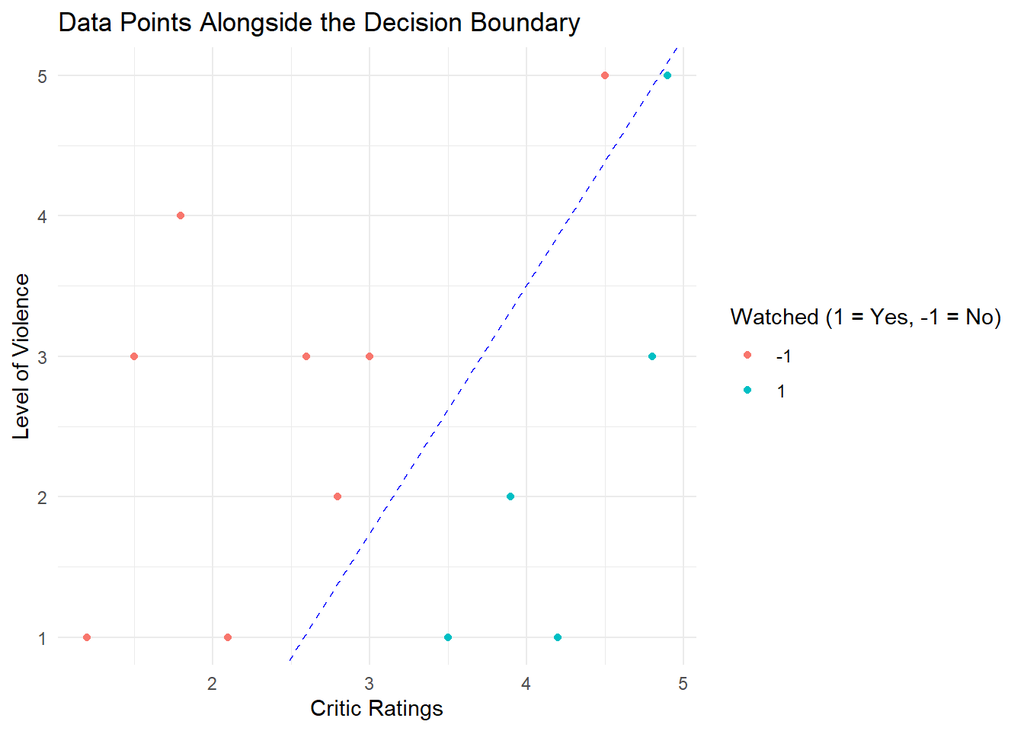

```r
plot_decision_boundary <- function(modelPla, data) {

  # get slope and intercept of decision boundary
  result <-  calculate_slope_and_intercept(modelPla)
  slope <- result$slope # get slope value
  intercept <- result$intercept # get intercept value

  # Visualize the data points along with the decision boundary
  ggplot(data, aes(x = CriticsRating, y = LevelOfViolence, color = factor(Watched))) +
  geom_point() +  # Scatter plot for the data points
  geom_abline(slope = slope, intercept = intercept, color = "blue", linetype = "dashed") + # Line segment for decesion boundary
  labs(title = "Data Points Alongside the Decision Boundary",
         x = "Critic Ratings",
         y = "Level of Violence",
         color = "Watched (1 = Yes, -1 = No)") +
  theme_minimal()  # Optimize this plot for better clarity

}

# This is a helper function to plot the decision boundary.
# This function renders the decision boundary alongside the data points from the dataset.
plot_decision_boundary(modelPla, df)
```